# GFW Media Analysis Test

Justin Rizzari

2026-03-13

# Introduction

This notebook will produce an analysis of fishing activity within the Mediterranean Sea in 2019 as part of the GFW Media Analyst role.

# Setup

Set default code chunk options

```r
knitr::opts_chunk$set(echo = TRUE, message = FALSE, warning = FALSE)
```

Load packages

```r
library(tidyverse)
library(bigrquery)
library(DBI)
library(fishwatchr)
library(glue)
library(lubridate)
library(here)
library(sf)
library(extrafont)
library(patchwork)
library(terra)
library(kableExtra)
library(gridExtra)
library(dplyr)
library(colorspace)
library(grid)
library(ggplot2)
library(tidyr)
library(dplyr)
library (gfwr)
library(stringr)
library(rnaturalearth)
library(rnaturalearthdata)
library(countrycode)
library(stringr)
library(rlang)
library(purrr)
library(patchwork)
library(cowplot)
```

Load the CSV data set

```r
# Load CSV
fishing_data <- read_csv(here("analyst_fishing_data.csv"))
```

Set some commonly used parameters for mapping

```r
# define bounding box/area of interest
bbox <- data.frame(x_min = -6,
                   x_max = 37,
                   y_min = 30,
                   y_max = 46)

# what longitude do we want to center maps on
best_center <- 15

# what projection should be used for mapping
# if you're having trouble with the dateline I recommend using this projection
best_proj <- str_c("+proj=eqearth +lon_0=", best_center, " +wktext", sep = "")

# resolution for fishing effort data
# 10 for 10th of a degree (0.1)
# 100 for 100th of a degree (0.01)
res <- 10
```

Load the two shapefiles of GFCM area 1 and 4.

```r
gfcm1_sf <- st_read(
  here("VME-DB_VME_GFCM_1", "closuresPolygon.shp")
) %>%
  fishwatchr::recenter_sf(center = best_center, proj = best_proj)
gfcm4_sf <- st_read(
  here("VME-DB_VME_GFCM_4", "other_areas.shp")
) %>%
  fishwatchr::recenter_sf(center = best_center, proj = best_proj)
```

# Summary

Calculate the total fishing hours, by gear type, inside both closure areas in 2019. I calculated the total fishing hours in 2019 inside the two GFCM closure areas by gear type. Fishing effort records were spatially intersected with the closure polygons, and total fishing hours were summed for each gear category within each closure and combined across both areas.

```r
# -----------------------------
# All gear classes present in dataset
# -----------------------------
all_gears <- fishing_data %>%
  filter(!is.na(fishing_class)) %>%
  distinct(fishing_class)

# -----------------------------
# Prepare closure polygons
# -----------------------------
closures_tbl <- bind_rows(
  gfcm1_sf %>% mutate(closure_area = "GFCM Closure Area 1"),
  gfcm4_sf %>% mutate(closure_area = "GFCM Closure Area 4")
) %>%
  st_make_valid() %>%
  st_transform(4326)

# -----------------------------
# Filter fishing data to 2019
# -----------------------------
fishing_2019 <- fishing_data %>%
  filter(
    year == 2019,
    !is.na(lon_bin),
    !is.na(lat_bin),
    !is.na(fishing_hours),
    !is.na(fishing_class)
  )

# -----------------------------
# Convert to sf points
# -----------------------------
fishing_2019_sf <- fishing_2019 %>%
  st_as_sf(coords = c("lon_bin", "lat_bin"), crs = 4326, remove = FALSE) %>%
  st_transform(st_crs(closures_tbl))

# -----------------------------
# Join fishing points to closures
# -----------------------------
fishing_inside_closures <- st_join(
  fishing_2019_sf,
  closures_tbl %>% select(closure_area),
  join = st_within,
  left = FALSE
)

# -----------------------------
# Clean gear labels
# -----------------------------
gear_labels <- function(x) {
  case_when(
    x == "dredge_fishing" ~ "Dredge Fishing",
    x == "purse_seines" ~ "Purse Seines",
    x == "pots_and_traps" ~ "Pots and Traps",
    x == "other_fishing" ~ "Other Fishing",
    x == "pole_and_line" ~ "Pole And Line",
    x == "squid_jigger" ~ "Squid Jigger",
    x == "trollers" ~ "Trollers",
    x == "fixed_gear" ~ "Fixed Gear",
    x == "other_seines" ~ "Other Seines",
    x == "fishing" ~ "Unspecified Fishing",
    x == "trawlers" ~ "Trawlers",
    x == "set_gillnets" ~ "Set Gillnets",
    x == "set_longlines" ~ "Set Longlines",
    x == "tuna_purse_seines" ~ "Tuna Purse Seines",
    x == "drifting_longlines" ~ "Drifting Longlines",
    x == "other_purse_seines" ~ "Other Purse Seines",
    TRUE ~ str_to_title(str_replace_all(x, "_", " "))
  )
}

# -----------------------------
# Summarise fishing hours inside closures
# -----------------------------
gear_by_closure <- fishing_inside_closures %>%
  st_drop_geometry() %>%
  group_by(fishing_class, closure_area) %>%
  summarise(
    fishing_hours = sum(fishing_hours, na.rm = TRUE),
    .groups = "drop"
  )

# -----------------------------
# Build complete table with all gear types
# -----------------------------
gear_hours_tbl <- all_gears %>%
  mutate(gear_type = gear_labels(fishing_class)) %>%
  left_join(gear_by_closure, by = "fishing_class") %>%
  select(gear_type, closure_area, fishing_hours) %>%
  complete(
    gear_type,
    closure_area = c("GFCM Closure Area 1", "GFCM Closure Area 4"),
    fill = list(fishing_hours = 0)
  ) %>%
  pivot_wider(
    names_from = closure_area,
    values_from = fishing_hours,
    values_fill = 0
  ) %>%
  mutate(
    Combined = `GFCM Closure Area 1` + `GFCM Closure Area 4`
  ) %>%
  mutate(
    across(
      c(`GFCM Closure Area 1`, `GFCM Closure Area 4`, Combined),
      ~ round(.x, 1)
    )
  ) %>%
  arrange(desc(Combined)) %>%
  select(
    gear_type,
    `GFCM Closure Area 1`,
    `GFCM Closure Area 4`,
    Combined
  )

# optional check
# names(gear_hours_tbl)
# ncol(gear_hours_tbl)

# -----------------------------
# Render table
# -----------------------------
kbl(
  gear_hours_tbl,
  col.names = c(
    "Gear type",
    "GFCM Closure Area 1",
    "GFCM Closure Area 4",
    "Combined"
  ),
  align = c("l", "r", "r", "r"),
  caption = "Total fishing hours by gear type inside GFCM closure areas in 2019"
) %>%
  kable_styling(full_width = FALSE)
```

Total fishing hours by gear type inside GFCM closure areas in 2019

| Gear type | GFCM Closure Area 1 | GFCM Closure Area 4 | Combined |
| --- | --- | --- | --- |
| Trawlers | 0.0 | 9468.9 | 9468.9 |
| Set Longlines | 0.0 | 1449.4 | 1449.4 |
| Unspecified Fishing | 0.0 | 108.9 | 108.9 |
| Drifting Longlines | 38.8 | 0.0 | 38.8 |
| Tuna Purse Seines | 0.0 | 18.8 | 18.8 |
| Set Gillnets | 0.0 | 6.5 | 6.5 |
| Dredge Fishing | 0.0 | 0.0 | 0.0 |
| Fixed Gear | 0.0 | 0.0 | 0.0 |
| Other Fishing | 0.0 | 0.0 | 0.0 |
| Other Purse Seines | 0.0 | 0.0 | 0.0 |
| Other Seines | 0.0 | 0.0 | 0.0 |
| Pole And Line | 0.0 | 0.0 | 0.0 |
| Pots and Traps | 0.0 | 0.0 | 0.0 |
| Purse Seines | 0.0 | 0.0 | 0.0 |
| Squid Jigger | 0.0 | 0.0 | 0.0 |
| Trollers | 0.0 | 0.0 | 0.0 |

Now lets export that table to a word document

```r
# Convert table to flextable
ft <- flextable(gear_hours_tbl)

# Format table
ft <- ft |>
  colformat_num(j = 2:4, digits = 1) |>
  align(j = 2:4, align = "right", part = "all") |>
  align(j = 1, align = "left", part = "all") |>
  bold(part = "header") |>
  autofit()

# Create Word document
doc <- read_docx() |>
  body_add_par("Total fishing hours by gear type inside GFCM closure areas in 2019", style = "heading 2") |>
  body_add_flextable(ft)

# Save document
print(doc, target = "closure_fishing_hours_2019.docx")
```

## Barplot

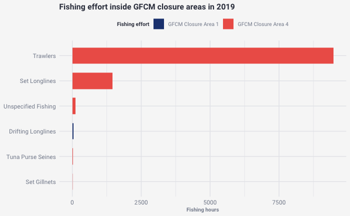

```r
# reshape and filter
gear_hours_plot <- gear_hours_tbl %>%
  pivot_longer(
    cols = c(`GFCM Closure Area 1`, `GFCM Closure Area 4`),
    names_to = "closure_area",
    values_to = "fishing_hours"
  ) %>%
  filter(fishing_hours > 0)

# bar chart
p_bar <- ggplot(
  gear_hours_plot,
  aes(x = reorder(gear_type, fishing_hours),
      y = fishing_hours,
      fill = closure_area)
) +
  geom_col(
    position = position_dodge(width = 0.7),
    width = 0.65
  ) +
  coord_flip() +
  labs(
    x = NULL,
    y = "Fishing hours",
    title = "Fishing effort inside GFCM closure areas in 2019"
  ) +
  scale_fill_manual(
    name = "Fishing effort",
    values = gfw_palette("chart")[c(1,5)]
  ) +
  theme_gfw() +
  theme(
    legend.position = "top",
    axis.text = element_text(size = 9),
    plot.title = element_text(size = 12)
  )

p_bar

ggsave(plot = last_plot(),
  filename = here::here ('figures','barplot.png'))
```

# Map

Let’s first make a general map that shows the two closure areas within the Mediterranean

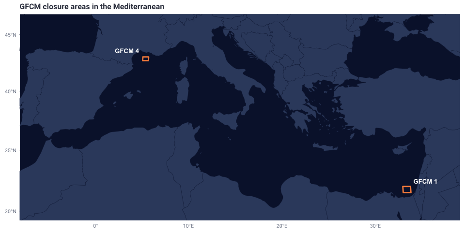

```r
# === Add label field to each shapefile before combining ===
gfcm1_lab <- gfcm1_sf %>%
  mutate(area_name = "GFCM 1")

gfcm4_lab <- gfcm4_sf %>%
  mutate(area_name = "GFCM 4")

# === Combine and project closure shapefiles ===
closure_sf <- bind_rows(gfcm1_lab, gfcm4_lab) %>%
  st_transform(best_proj)

# === Create centroid label points ===
closure_labels <- closure_sf %>%
  st_centroid()

# === Set bounding box for Mediterranean map ===
bounding_med <- transform_box(
  xlim = c(bbox[1, "x_min"], bbox[1, "x_max"]),
  ylim = c(bbox[1, "y_min"], bbox[1, "y_max"]),
  output_crs = best_proj
)

# === Generate locator map ===
p_med_closures <- ggplot() +
  geom_sf(
    data = closure_sf,
    fill = NA,
    color = gfw_palette("orange")[1],
    linewidth = 1
  ) +
  geom_gfw_land(center = best_center) +
  geom_sf_text(
    data = closure_labels %>% filter(area_name == "GFCM 1"),
    aes(label = area_name),
    nudge_x = 180000,
    nudge_y = 80000,
    size = 3.5,
    fontface = "bold",
    color = "white"
  ) +
  geom_sf_text(
    data = closure_labels %>% filter(area_name == "GFCM 4"),
    aes(label = area_name),
    nudge_x = -180000,
    nudge_y = 80000,
    size = 3.5,
    fontface = "bold",
    color = "white"
  ) +
  labs(
    title = "GFCM closure areas in the Mediterranean"
  ) +
  theme_gfw_map() +
  theme(
    plot.title = element_text(size = 12),
    axis.title = element_blank(),
    axis.text = element_text(size = 8)
  ) +
  coord_sf(
    xlim = c(bounding_med$box_out[["xmin"]], bounding_med$box_out[["xmax"]]),
    ylim = c(bounding_med$box_out[["ymin"]], bounding_med$box_out[["ymax"]]),
    crs = bounding_med$out_crs
  )

# === Show map ===
p_med_closures
```

Now lets generate zoomed-in maps of fishing effort around the two GFCM closure areas. Fishing hours are aggregated by grid cell and mapped as a raster surface, with all layers projected to a common coordinate reference system to ensure spatial alignment. Closure boundaries are overlaid to show fishing activity occurring within and around each area.

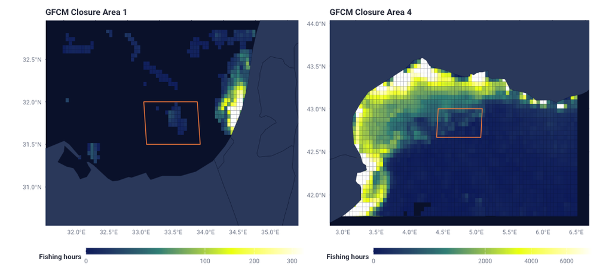

```r
# -----------------------------
# Settings
# -----------------------------
best_center <- 15
best_proj <- str_c("+proj=eqearth +lon_0=", best_center, " +wktext", sep = "")

# -----------------------------
# Build fishing effort layer
# -----------------------------
f_hours_grid <- fishing_data %>%
  dplyr::select(lon_bin, lat_bin, fishing_hours) %>%
  filter(
    !is.na(lon_bin),
    !is.na(lat_bin),
    !is.na(fishing_hours)
  ) %>%
  group_by(lon_bin, lat_bin) %>%
  summarise(fishing_hours = sum(fishing_hours, na.rm = TRUE), .groups = "drop") %>%
  filter(is.finite(fishing_hours), fishing_hours > 0) %>%
  fishwatchr::recenter_raster(
    x_lab = "lon_bin",
    y_lab = "lat_bin",
    fill_lab = "fishing_hours",
    res = 0.05,
    center = best_center
  ) %>%
  terra::rast(type = "xyz", crs = best_proj) %>%
  terra::as.polygons(dissolve = FALSE) %>%
  st_as_sf()

names(f_hours_grid)[1] <- "fishing_hours"

# -----------------------------
# Make geometries valid and use same CRS
# -----------------------------
f_hours_map <- f_hours_grid %>%
  st_make_valid() %>%
  st_transform(best_proj)

gfcm1_map <- gfcm1_sf %>%
  st_make_valid() %>%
  st_transform(best_proj)

gfcm4_map <- gfcm4_sf %>%
  st_make_valid() %>%
  st_transform(best_proj)

# Remove empty geometries if any
f_hours_map <- f_hours_map[!st_is_empty(f_hours_map), ]
gfcm1_map   <- gfcm1_map[!st_is_empty(gfcm1_map), ]
gfcm4_map   <- gfcm4_map[!st_is_empty(gfcm4_map), ]

# -----------------------------
# Helper for tighter zoom bbox
# -----------------------------
get_bbox_limits <- function(sf_obj, pad_x = 120000, pad_y = 100000) {
  bb <- st_bbox(sf_obj)
  list(
    xlim = c(as.numeric(bb["xmin"]) - pad_x, as.numeric(bb["xmax"]) + pad_x),
    ylim = c(as.numeric(bb["ymin"]) - pad_y, as.numeric(bb["ymax"]) + pad_y)
  )
}

lim_gfcm1 <- get_bbox_limits(gfcm1_map, pad_x = 120000, pad_y = 100000)
lim_gfcm4 <- get_bbox_limits(gfcm4_map, pad_x = 120000, pad_y = 100000)

# -----------------------------
# Crop fishing effort around each closure
# -----------------------------
f_hours_1 <- suppressWarnings(
  st_crop(
    f_hours_map,
    xmin = lim_gfcm1$xlim[1],
    xmax = lim_gfcm1$xlim[2],
    ymin = lim_gfcm1$ylim[1],
    ymax = lim_gfcm1$ylim[2]
  )
)

f_hours_4 <- suppressWarnings(
  st_crop(
    f_hours_map,
    xmin = lim_gfcm4$xlim[1],
    xmax = lim_gfcm4$xlim[2],
    ymin = lim_gfcm4$ylim[1],
    ymax = lim_gfcm4$ylim[2]
  )
)

# -----------------------------
# Safe helper for local scale max
# -----------------------------
safe_scale_max <- function(sf_obj, fallback = 1) {
  if (nrow(sf_obj) == 0) return(fallback)

  vals <- sf_obj$fishing_hours
  vals <- vals[is.finite(vals) & !is.na(vals)]

  if (length(vals) == 0) return(fallback)
  if (length(vals) == 1) return(vals)

  out <- suppressWarnings(quantile(vals, 0.95, na.rm = TRUE, names = FALSE))

  if (!is.finite(out) || is.na(out) || out <= 0) {
    out <- max(vals, na.rm = TRUE)
  }

  if (!is.finite(out) || is.na(out) || out <= 0) out <- fallback

  out
}

zoom_max_1 <- safe_scale_max(f_hours_1, fallback = 1)
zoom_max_4 <- safe_scale_max(f_hours_4, fallback = 1)

# -----------------------------
# Map 1
# -----------------------------
p_gfcm1 <- ggplot() +
  geom_sf(
    data = f_hours_1,
    aes(fill = fishing_hours),
    color = NA
  ) +
  geom_sf(
    data = gfcm1_map,
    fill = NA,
    color = gfw_palette("orange")[1],
    linewidth = 0.5
  ) +
  geom_gfw_land(center = best_center) +
  labs(
    title = "GFCM Closure Area 1",
    fill = "Fishing hours"
  ) +
  scale_fill_gradientn(
    colours = gfw_palette("map_effort_dark"),
    limits = c(0, zoom_max_1),
    oob = scales::squish,
    trans = "sqrt",
    na.value = NA
  ) +
  theme_gfw_map() +
  theme(
    plot.title = element_text(size = 11),
    axis.title = element_blank(),
    axis.text = element_text(size = 8),
    legend.position = "bottom",
    legend.title = element_text(size = 9),
    legend.text = element_text(size = 8)
  ) +
  coord_sf(
    xlim = lim_gfcm1$xlim,
    ylim = lim_gfcm1$ylim,
    crs = st_crs(gfcm1_map)
  )

# -----------------------------
# Map 2
# -----------------------------
p_gfcm4 <- ggplot() +
  geom_sf(
    data = f_hours_4,
    aes(fill = fishing_hours),
    color = NA
  ) +
  geom_sf(
    data = gfcm4_map,
    fill = NA,
    color = gfw_palette("orange")[1],
    linewidth = 0.5
  ) +
  geom_gfw_land(center = best_center) +
  labs(
    title = "GFCM Closure Area 4",
    fill = "Fishing hours"
  ) +
  scale_fill_gradientn(
    colours = gfw_palette("map_effort_dark"),
    limits = c(0, zoom_max_4),
    oob = scales::squish,
    trans = "sqrt",
    na.value = NA
  ) +
  theme_gfw_map() +
  theme(
    plot.title = element_text(size = 11),
    axis.title = element_blank(),
    axis.text = element_text(size = 8),
    legend.position = "bottom",
    legend.title = element_text(size = 9),
    legend.text = element_text(size = 8)
  ) +
  coord_sf(
    xlim = lim_gfcm4$xlim,
    ylim = lim_gfcm4$ylim,
    crs = st_crs(gfcm4_map)
  )

# -----------------------------
# Combine into one figure
# -----------------------------
p_gfcm1 + p_gfcm4
```

Now lets combine those figures into one final figure

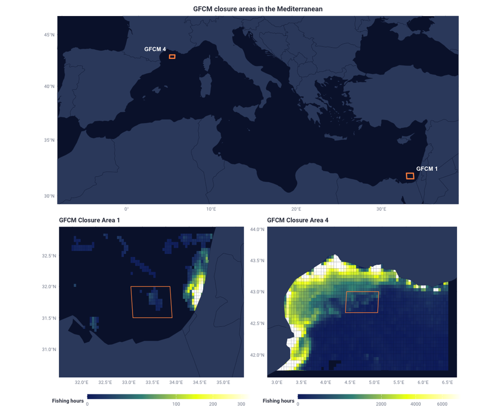

```r
p_med_closures <- p_med_closures +
  theme(
    plot.title = element_text(hjust = 0.5)
  )

final_map <- p_med_closures /
             (p_gfcm1 | p_gfcm4) +
             plot_layout(heights = c(1.25, 1))

final_map
```

```r
ggsave(plot = last_plot(),
  filename = here::here ('figures','overall_map.png'))
```

Now lets create a figure showing the closure areas overlaid with fishing effort for trawlers and longliners. We have two types of longliners so we combine “drifting_longlines” and “set_longlines”

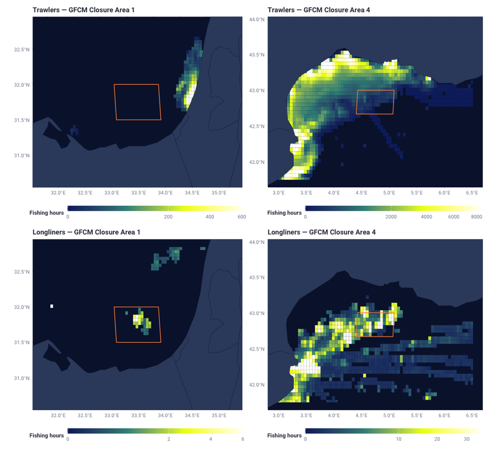

```r
# -----------------------------
# Settings
# -----------------------------
best_center <- 15
best_proj <- str_c("+proj=eqearth +lon_0=", best_center, " +wktext", sep = "")

# -----------------------------
# Recode fishing classes into two gear groups
# -----------------------------
fishing_gear <- fishing_data %>%
  mutate(
    gear_group = case_when(
      fishing_class == "trawlers" ~ "Trawlers",
      fishing_class %in% c("set_longlines", "drifting_longlines") ~ "Longliners",
      TRUE ~ NA_character_
    )
  ) %>%
  filter(
    !is.na(gear_group),
    !is.na(lon_bin),
    !is.na(lat_bin),
    !is.na(fishing_hours)
  ) %>%
  group_by(gear_group, lon_bin, lat_bin) %>%
  summarise(fishing_hours = sum(fishing_hours, na.rm = TRUE), .groups = "drop") %>%
  filter(is.finite(fishing_hours), fishing_hours > 0)

# -----------------------------
# Convert gridded effort to sf polygons by gear group
# -----------------------------
build_effort_sf <- function(df) {
  out <- df %>%
    fishwatchr::recenter_raster(
      x_lab = "lon_bin",
      y_lab = "lat_bin",
      fill_lab = "fishing_hours",
      res = 0.05,
      center = best_center
    ) %>%
    terra::rast(type = "xyz", crs = best_proj) %>%
    terra::as.polygons(dissolve = FALSE) %>%
    st_as_sf() %>%
    st_make_valid() %>%
    st_transform(best_proj)

  names(out)[1] <- "fishing_hours"
  out <- out[!st_is_empty(out), ]
  out
}

f_trawlers_map <- fishing_gear %>%
  filter(gear_group == "Trawlers") %>%
  build_effort_sf()

f_longliners_map <- fishing_gear %>%
  filter(gear_group == "Longliners") %>%
  build_effort_sf()

# -----------------------------
# Prepare closure layers
# -----------------------------
gfcm1_map <- gfcm1_sf %>%
  st_make_valid() %>%
  st_transform(best_proj)

gfcm4_map <- gfcm4_sf %>%
  st_make_valid() %>%
  st_transform(best_proj)

gfcm1_map <- gfcm1_map[!st_is_empty(gfcm1_map), ]
gfcm4_map <- gfcm4_map[!st_is_empty(gfcm4_map), ]

# -----------------------------
# Helper for tight zoom around each closure
# -----------------------------
get_bbox_limits <- function(sf_obj, pad_x = 120000, pad_y = 100000) {
  bb <- st_bbox(sf_obj)
  list(
    xlim = c(as.numeric(bb["xmin"]) - pad_x, as.numeric(bb["xmax"]) + pad_x),
    ylim = c(as.numeric(bb["ymin"]) - pad_y, as.numeric(bb["ymax"]) + pad_y)
  )
}

lim_gfcm1 <- get_bbox_limits(gfcm1_map, pad_x = 120000, pad_y = 100000)
lim_gfcm4 <- get_bbox_limits(gfcm4_map, pad_x = 120000, pad_y = 100000)

# -----------------------------
# Crop effort around each closure
# -----------------------------
crop_effort <- function(sf_obj, limits) {
  suppressWarnings(
    st_crop(
      sf_obj,
      xmin = limits$xlim[1],
      xmax = limits$xlim[2],
      ymin = limits$ylim[1],
      ymax = limits$ylim[2]
    )
  )
}

f_trawlers_1   <- crop_effort(f_trawlers_map, lim_gfcm1)
f_trawlers_4   <- crop_effort(f_trawlers_map, lim_gfcm4)
f_longliners_1 <- crop_effort(f_longliners_map, lim_gfcm1)
f_longliners_4 <- crop_effort(f_longliners_map, lim_gfcm4)

# -----------------------------
# Helper for local scale max
# -----------------------------
safe_scale_max <- function(sf_obj, fallback = 1) {
  if (nrow(sf_obj) == 0) return(fallback)

  vals <- sf_obj$fishing_hours
  vals <- vals[is.finite(vals) & !is.na(vals)]

  if (length(vals) == 0) return(fallback)
  if (length(vals) == 1) return(vals)

  out <- suppressWarnings(quantile(vals, 0.95, na.rm = TRUE, names = FALSE))

  if (!is.finite(out) || is.na(out) || out <= 0) {
    out <- max(vals, na.rm = TRUE)
  }

  if (!is.finite(out) || is.na(out) || out <= 0) out <- fallback
  out
}

zoom_max_trawlers_1   <- safe_scale_max(f_trawlers_1)
zoom_max_trawlers_4   <- safe_scale_max(f_trawlers_4)
zoom_max_longliners_1 <- safe_scale_max(f_longliners_1)
zoom_max_longliners_4 <- safe_scale_max(f_longliners_4)

# -----------------------------
# Helper to build panel maps
# -----------------------------
make_panel_map <- function(effort_sf, closure_sf, limits, panel_title, scale_max) {
  ggplot() +
    geom_sf(
      data = effort_sf,
      aes(fill = fishing_hours),
      color = NA
    ) +
    geom_sf(
      data = closure_sf,
      fill = NA,
      color = gfw_palette("orange")[1],
      linewidth = 0.5
    ) +
    geom_gfw_land(center = best_center) +
    labs(
      title = panel_title,
      fill = "Fishing hours"
    ) +
    scale_fill_gradientn(
      colours = gfw_palette("map_effort_dark"),
      limits = c(0, scale_max),
      oob = scales::squish,
      trans = "sqrt",
      na.value = NA
    ) +
    theme_gfw_map() +
    theme(
      plot.title = element_text(size = 11),
      axis.title = element_blank(),
      axis.text = element_text(size = 8),
      legend.position = "bottom",
      legend.title = element_text(size = 9),
      legend.text = element_text(size = 8)
    ) +
    coord_sf(
      xlim = limits$xlim,
      ylim = limits$ylim,
      crs = st_crs(closure_sf)
    )
}

# -----------------------------
# Build four panels
# -----------------------------
p_trawlers_1 <- make_panel_map(
  effort_sf   = f_trawlers_1,
  closure_sf  = gfcm1_map,
  limits      = lim_gfcm1,
  panel_title = "Trawlers — GFCM Closure Area 1",
  scale_max   = zoom_max_trawlers_1
)

p_trawlers_4 <- make_panel_map(
  effort_sf   = f_trawlers_4,
  closure_sf  = gfcm4_map,
  limits      = lim_gfcm4,
  panel_title = "Trawlers — GFCM Closure Area 4",
  scale_max   = zoom_max_trawlers_4
)

p_longliners_1 <- make_panel_map(
  effort_sf   = f_longliners_1,
  closure_sf  = gfcm1_map,
  limits      = lim_gfcm1,
  panel_title = "Longliners — GFCM Closure Area 1",
  scale_max   = zoom_max_longliners_1
)

p_longliners_4 <- make_panel_map(
  effort_sf   = f_longliners_4,
  closure_sf  = gfcm4_map,
  limits      = lim_gfcm4,
  panel_title = "Longliners — GFCM Closure Area 4",
  scale_max   = zoom_max_longliners_4
)

# -----------------------------
# Combine into four-panel figure
# -----------------------------
library(patchwork)

four_panel_map <-
  (p_trawlers_1 | p_trawlers_4) /
  (p_longliners_1 | p_longliners_4)

four_panel_map
```

```r
ggsave(plot = last_plot(),
  filename = here::here ('figures','map_effort_by_gear.png'))
```